# Sup_Learning

### TomekLinks

Given two instances a and b belonging to different classes and are separated by a distance d(a,b), the pair (a, b) is called a Tomek link if there is no instance c such that d(a,c) < d(a,b) or d(b,c) < d(a,b). Instances participating in Tomek links are either borderline or noise so both are removed.

```python
# TomekLinks
sampler = TomekLinks()
X_rs, y_rs = sampler.fit_resample(x_train, y_train)
print('TomekLinks undersampling {}'.format(Counter(y_rs)))
```

```
TomekLinks undersampling Counter({'loan_default': 1})
```

```python
y_rs.value_counts()
```

```
loan_default
0               46838
1               12390
dtype: int64
```

This method keeps more non-default values than previous methods

#### H2O Modeling

```python
train, valid, test = H2odf(X_rs, x_test, y_rs, y_test)
train.shape
```

```
Parse progress: |████████████████████████████████████████████████████████████████| (done) 100%
Parse progress: |████████████████████████████████████████████████████████████████| (done) 100%
```

```
(47383, 85)
```

```python
# make sure this is a classfication issue
train['loan_default'] = train['loan_default'].asfactor()
# train the model
forest1.train(x=list(x_test.columns), y='loan_default', training_frame=train, validation_frame=valid);
```

```
drf Model Build progress: |██████████████████████████████████████████████████████| (done) 100%
```

```
drf prediction progress: |███████████████████████████████████████████████████████| (done) 100%

   * ROC curve: The ROC curve plots the true positive rate vs. the false rositive sate

	  * The area under the curve (AUC): A value between 0.5 (random) and 1.0 (perfect), measuring the prediction accuracy

   * Recall (R) = The number of true positives / (the number of true positives + the number of false negatives)
```

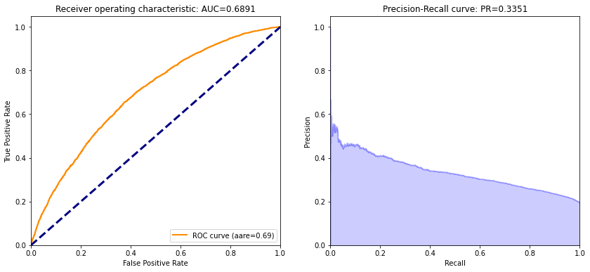

```python
ROC_AUC1(forest1, test, 'loan_default') # use p1 in y_pred
```

Lower than the Neighbourhood Cleaning Rule model and my first model

```python
createGains(forest1)
```

```
drf prediction progress: |███████████████████████████████████████████████████████| (done) 100%
```

| decile | count | actual | non_actual | cum_count | cum_actual | cum_non_actual | percent_cum_actual | percent_cum_non_actual | if_random | lift | K_S | gain |
| --- | --- | --- | --- | --- | --- | --- | --- | --- | --- | --- | --- | --- |
| 0 | 1600 | 468 | 1132 | 1600 | 468 | 1132 | 0.15 | 0.09 | 309.8 | 1.51 | 6.0 | 29.25 |
| 1 | 1600 | 464 | 1136 | 3200 | 932 | 2268 | 0.30 | 0.18 | 619.6 | 1.50 | 12.0 | 29.12 |
| 2 | 1600 | 465 | 1135 | 4800 | 1397 | 3403 | 0.45 | 0.26 | 929.4 | 1.50 | 19.0 | 29.10 |
| 3 | 1600 | 476 | 1124 | 6400 | 1873 | 4527 | 0.60 | 0.35 | 1239.2 | 1.51 | 25.0 | 29.27 |
| 4 | 1600 | 313 | 1287 | 8000 | 2186 | 5814 | 0.71 | 0.45 | 1549.0 | 1.41 | 26.0 | 27.32 |
| 5 | 1600 | 190 | 1410 | 9600 | 2376 | 7224 | 0.77 | 0.56 | 1858.8 | 1.28 | 21.0 | 24.75 |
| 6 | 1600 | 201 | 1399 | 11200 | 2577 | 8623 | 0.83 | 0.67 | 2168.6 | 1.19 | 16.0 | 23.01 |
| 7 | 1600 | 173 | 1427 | 12800 | 2750 | 10050 | 0.89 | 0.78 | 2478.4 | 1.11 | 11.0 | 21.48 |
| 8 | 1600 | 177 | 1423 | 14400 | 2927 | 11473 | 0.94 | 0.89 | 2788.2 | 1.05 | 5.0 | 20.33 |
| 9 | 1600 | 171 | 1429 | 16000 | 3098 | 12902 | 1.00 | 1.00 | 3098.0 | 1.00 | 0.0 | 19.36 |

Fine

## Over-Sampling

```python
from imblearn.over_sampling import *
```

### RandomOverSampler

Random oversampling simply replicate randomly the minority class examples. Random oversampling is known to increase the likelihood of occurring overfitting. On the other hand, the major drawback of Random undersampling is that this method can discard useful data.

```python
y_train.value_counts()
```

```
loan_default
0               51610
1               12390
dtype: int64
```

```python
# RandomOverSampler
# sample from 12390 to 20000
sampler = RandomOverSampler(sampling_strategy={1: 20000, 0: 51610})
X_rs, y_rs = sampler.fit_resample(x_train, y_train)
print('RandomOverSampler {}'.format(Counter(y_rs)))
```

```
RandomOverSampler Counter({'loan_default': 1})
```

My selection of oversampling number is kind of arbitary, I want to know more about how to decide the oversampling number

#### H2O Modeling

```python
train, valid, test = H2odf(X_rs, x_test, y_rs, y_test)
train.shape
```

```
Parse progress: |████████████████████████████████████████████████████████████████| (done) 100%
Parse progress: |████████████████████████████████████████████████████████████████| (done) 100%
```

```
(57284, 85)
```

```python
# make sure this is a classfication issue
train['loan_default'] = train['loan_default'].asfactor()
# train the model
forest1.train(x=list(x_test.columns), y='loan_default', training_frame=train, validation_frame=valid);
```

```
drf prediction progress: |███████████████████████████████████████████████████████| (done) 100%

   * ROC curve: The ROC curve plots the true positive rate vs. the false rositive sate

	  * The area under the curve (AUC): A value between 0.5 (random) and 1.0 (perfect), measuring the prediction accuracy

   * Recall (R) = The number of true positives / (the number of true positives + the number of false negatives)
```

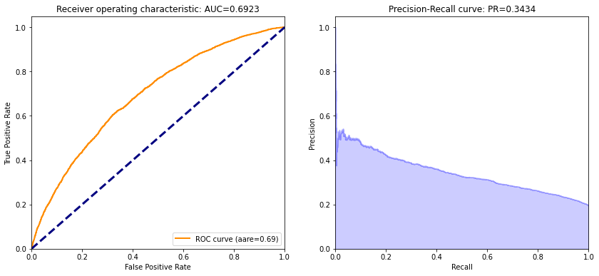

```python
ROC_AUC1(forest1, test, 'loan_default')
```

Over-sampling rises the model performance, this is great

```python
createGains(forest1)
```

```
drf prediction progress: |███████████████████████████████████████████████████████| (done) 100%
```

| decile | count | actual | non_actual | cum_count | cum_actual | cum_non_actual | percent_cum_actual | percent_cum_non_actual | if_random | lift | K_S | gain |
| --- | --- | --- | --- | --- | --- | --- | --- | --- | --- | --- | --- | --- |
| 0 | 1600 | 661 | 939 | 1600 | 661 | 939 | 0.21 | 0.07 | 309.8 | 2.13 | 14.0 | 41.31 |
| 1 | 1600 | 514 | 1086 | 3200 | 1175 | 2025 | 0.38 | 0.16 | 619.6 | 1.90 | 22.0 | 36.72 |
| 2 | 1600 | 390 | 1210 | 4800 | 1565 | 3235 | 0.51 | 0.25 | 929.4 | 1.68 | 26.0 | 32.60 |
| 3 | 1600 | 377 | 1223 | 6400 | 1942 | 4458 | 0.63 | 0.35 | 1239.2 | 1.57 | 28.0 | 30.34 |
| 4 | 1600 | 295 | 1305 | 8000 | 2237 | 5763 | 0.72 | 0.45 | 1549.0 | 1.44 | 27.0 | 27.96 |
| 5 | 1600 | 257 | 1343 | 9600 | 2494 | 7106 | 0.81 | 0.55 | 1858.8 | 1.34 | 26.0 | 25.98 |
| 6 | 1600 | 224 | 1376 | 11200 | 2718 | 8482 | 0.88 | 0.66 | 2168.6 | 1.25 | 22.0 | 24.27 |
| 7 | 1600 | 167 | 1433 | 12800 | 2885 | 9915 | 0.93 | 0.77 | 2478.4 | 1.16 | 16.0 | 22.54 |
| 8 | 1600 | 127 | 1473 | 14400 | 3012 | 11388 | 0.97 | 0.88 | 2788.2 | 1.08 | 9.0 | 20.92 |
| 9 | 1600 | 86 | 1514 | 16000 | 3098 | 12902 | 1.00 | 1.00 | 3098.0 | 1.00 | 0.0 | 19.36 |

Perfect

### ADASYN: Adaptive Synthetic Sampling

ADASYN generates samples of the minority class according to their density distributions. More synthetic data is generated for minority class samples that are harder to learn, compared to those minority samples that are easier to learn. It calculates the K-nearest neighbors of each minority instance, then gets the class ratio of the minority and majority instances to generate new samples. Repeating this process adaptively shifts the decision boundary to focus on those samples that are difficult to learn.

```python
# we use the same sampling number
# sampler = ADASYN(sampling_strategy={1: 20000, 0: 51610})
# X_rs, y_rs = sampler.fit_resample(x_train, y_train)
# print('ADASYN {}'.format(Counter(y_rs)))
```

[output not shown]

#### H2O Modeling

My memory cannot run this, so I skip it for now

```python
# train, valid, test = H2odf(X_rs, x_test, y_rs, y_test)
# train.shape
```

```python
# make sure this is a classfication issue
# train['loan_default'] = train['loan_default'].asfactor()
# train the model
# forest1.train(x=list(x_test.columns), y='loan_default', training_frame=train, validation_frame=valid);
```

```python
# ROC_AUC1(forest1, test, 'loan_default')
```

```python
#createGains(forest1)
```